# What is a density surface model?

### Why model abundance spatially?

- Use non-designed surveys
- Use environmental information
- Maps

## Back to Horvitz-Thompson estimation

### Horvitz-Thompson-like estimators

- Rescale the (flat) density and extrapolate

\[ \hat{N} = \frac{\text{study area}}{\text{covered area}}\sum_{i=1}^n \frac{s_i}{\hat{p}_i} \]

- \( s_i \) are group/cluster sizes
- \( \hat{p}_i \) is the detection probability (from detection function)

### Hidden in this formula is a simple assumption

- Probability of sampling every point in the study area is equal
- Is this true? Sometimes.
- If (and only if) the design is randomised

### Many faces of randomisation

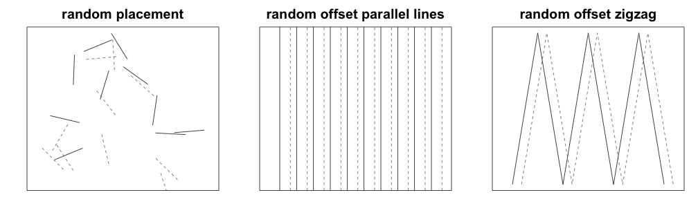

### Randomisation & coverage probability

- H-T equation above assumes even coverage
  - (or you can estimate)

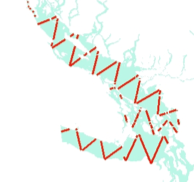

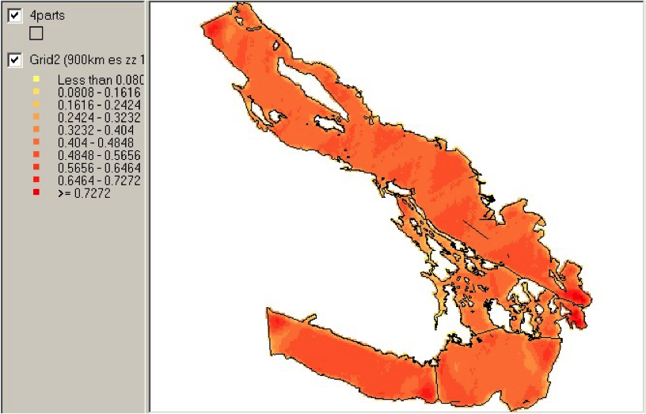

### Extra information

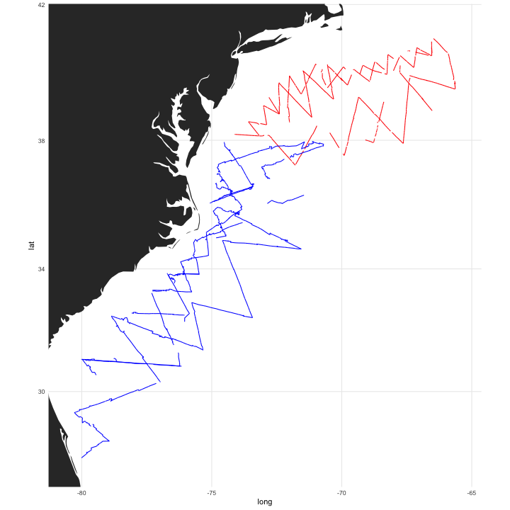

### Extra information - depth

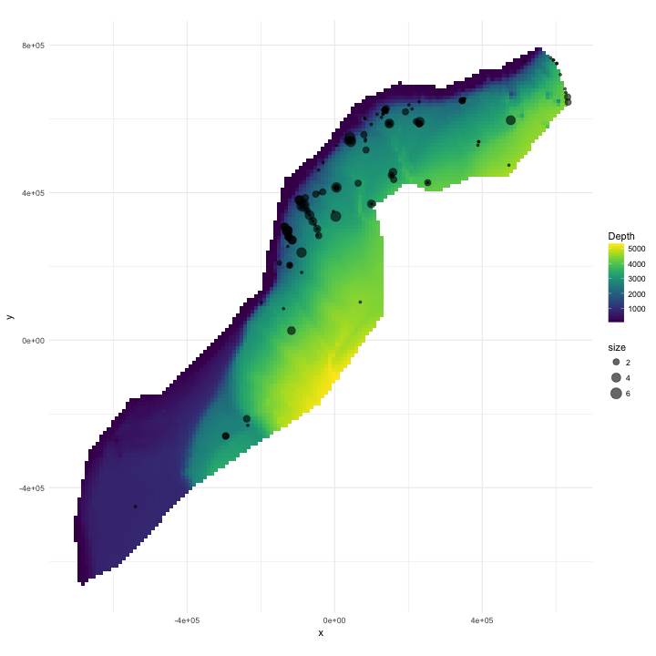

### Extra information - depth

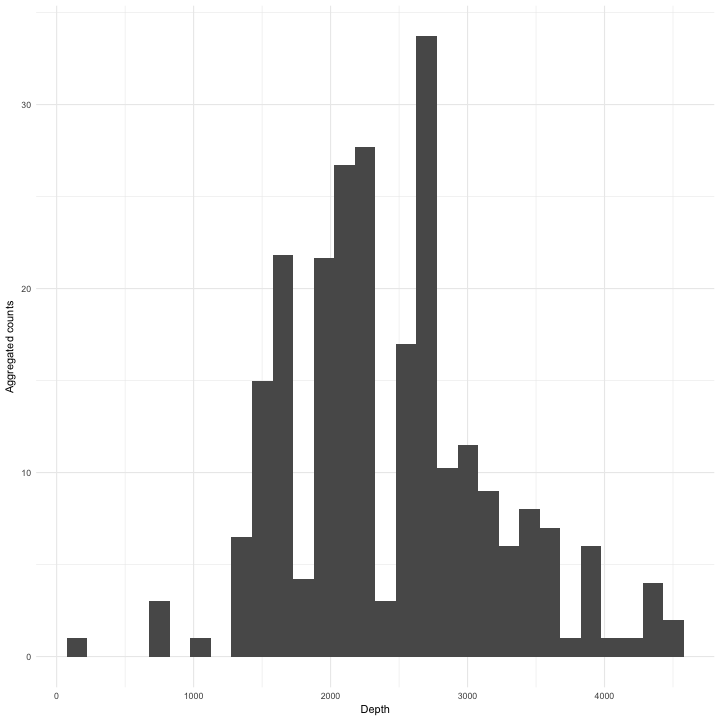

- NB this only shows segments where counts > 0

### Extra information - SST

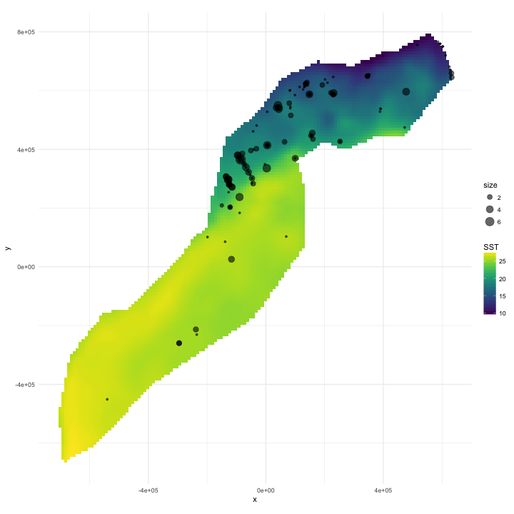

### Extra information - SST

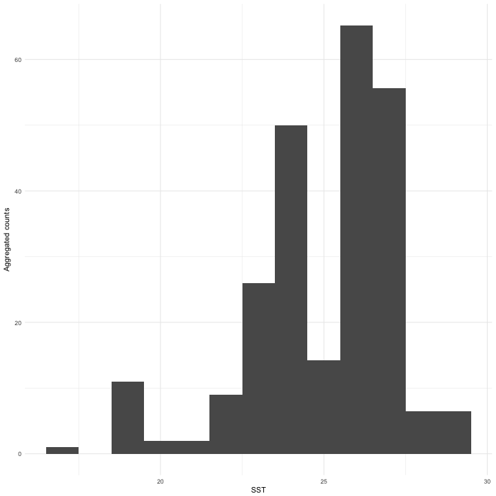

- (only segments where counts > 0)

## You should model that

### Modelling outputs

- Abundance and uncertainty
  - Arbitrary areas
  - Numeric values
  - Maps
  - Extrapolation (with caution!)
- Covariate effects
  - count/sample as function of covars

### Modelling requirements

- Include detectability
- Account for effort
- Flexible/interpretable effects
- Predictions over an arbitrary area

## Accounting for effort

### Effort

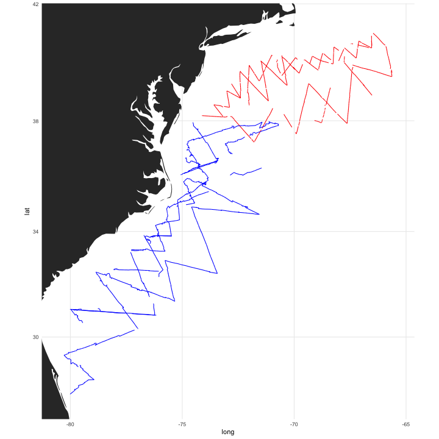

- Have transects
- Variation in counts and covars along them
- Want a sample unit w/ minimal variation
- “Segments”: chunks of effort

### Chopping up transects

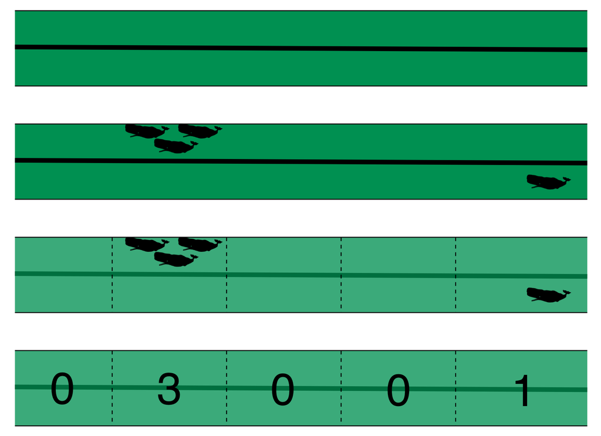

[Physeter catodon by Noah Schlottman](http://phylopic.org/image/dc76cbdb-dba5-4d8f-8cf3-809515c30dbd/)

## Flexible, interpretable effects

### Smooth response

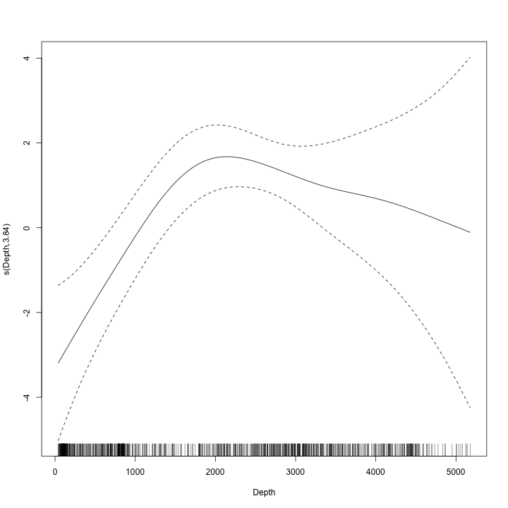

### Explicit spatial effects

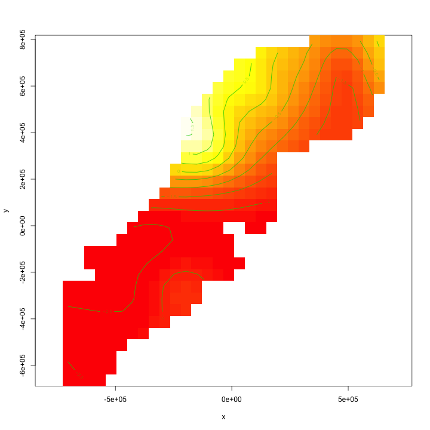

## Predictions

### Predictions over an arbitrary area

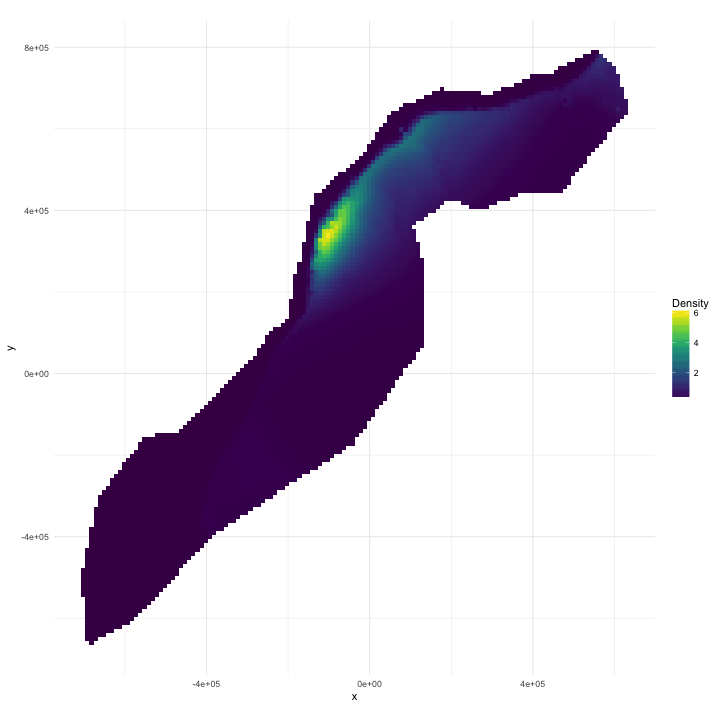

- Don't want to be restricted to predict on segments
- Predict within survey area
- Extrapolate outside (with caution)
- Working on a grid of cells

## Detection information

### Including detection information

- Two options:
  - adjust areas to account for **effective effort**
  - use **Horvitz-Thompson estimates** as response

### Effective effort

- Area of each segment, \( A_j \)
  - use \( A_j\hat{p}_j \)
- think effective strip width (\( \hat{\mu} = w\hat{p} \))
- Response is counts per segment
- “Adjusting for effort”
- “Count model”

### Estimated abundance

- Estimate H-T abundance per segment
- Effort is area of each segment
- “Estimated abundance” per segment

\[ \hat{n}_j = \sum_{i \text{ in segment } j } \frac{s_i}{\hat{p}_i} \]

### Detectability and covariates

- 2 covariate “levels” in detection function
  - “Observer”/“observation” – change **within** segment
  - “Segment” – change **between** segments
- “Count model” only lets us use segment-level covariates
- “Estimated abundance” lets us use either

### When to use each approach?

- Generally “nicer” to adjust effort
- Keep response (counts) close to what was observed
- **Unless** you want observation-level covariates
  - These *can* make a big difference!

### Availability, perception bias and more

- \( \hat{p} \) is not always simple!
- Availability & perception bias somehow enter
- We can make explicit models for this
- More later in the course

### DSM flow diagram

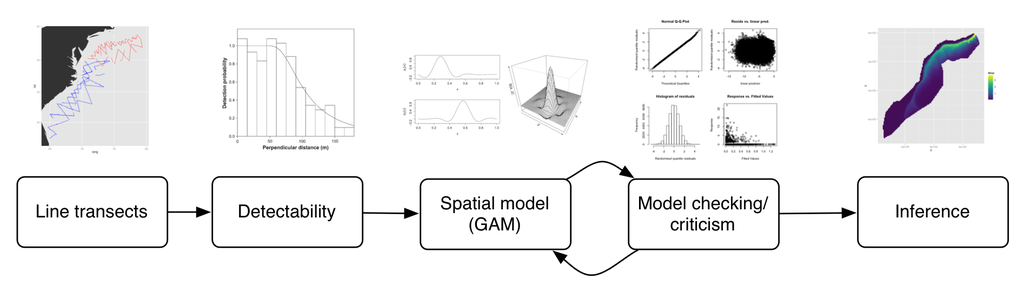

## Spatial models

### Abundance as a function of covariates

- Two approaches to model abundance
- Explicit spatial models
  - When: good coverage, fixed area
- “Habitat” models (no explicit spatial terms)
  - When: poorer coverage, extrapolation
- We'll cover both approaches here

## Data requirements

### What do we need?

- Need to “link” data
- Distance data/detection function
- Segment data
- Observation data to link segments to detections

### Recap

- Model counts or estimated abundace
- The effort is accounted for differently
- Flexible models are good
- Incorporate detectability
- 2 tables + detection function needed